# Final FCD Analysis

Sarah Van Dyk

2024-08-12

#Code file for Victims and defendants in federal human trafficking prosecutions ## Request for data or questions about code can be directed to Sarah Sowell Van Dyk - sarah.e.sowell@vanderbilt.edu ## Chunks are ordered by their presentation in the paper, with loading and cleaning included at the beginning ##Many summary statistics in the paper are stored in tidles, for ease of marking down this file, view commands are commented out - to view summary statistics, remove #.

#Load Library

```r
library(dplyr)
library(purrr)
library(mice)
library(plm)
library(lme4)
library(MASS)
library(missMethods)
library(ggridges)
library(ggeffects)
library(stringr)
library(broom)
library(broom.mixed)
library(reshape2)
library(tidyverse)
```

#Load Data

```r
#Check Version
R.version.string
```

```
## [1] "R version 4.4.1 (2024-06-14)"
```

```r
#Set Working Directory
getwd()
```

```
## [1] "/Users/sarahsowell/Downloads"
```

```r
setwd("/Users/sarahsowell/Downloads")




# Read in all Relevant Data
allCase <- read.csv("cases updated.csv")
allDef <- read.csv("defendant.csv")
allCrime <- read.csv("crime location (3).csv")


#Create Defendant level data with all case information - this is the data frame used for any analysis done at the defendant level
lightHouse <- left_join(
  allDef,
  allCase,
  by = "case_id",
  copy = TRUE,
  suffix = c(".x", ".y"),
  multiple = "all"
)


# For reference: allCase is data at case level unit of analysis, lightHouse is data at defendant level of analysis
```

#Create Variables as Needed

```r
library(stringr)

#Case Level Trafficking Binary
allCase$sex_labor <- ifelse(str_detect(allCase$trafficking_type_multiple, "Minor Sex Trafficking"), 1, NA)

allCase$sex_labor <- ifelse(str_detect(allCase$trafficking_type_multiple, "Adult Sex Trafficking"), 1, allCase$sex_labor)

allCase$sex_labor <- ifelse(str_detect(allCase$trafficking_type_multiple, "Labor Trafficking"), 0, allCase$sex_labor)

allCase$sex_labor <- ifelse(str_detect(allCase$trafficking_type_multiple, "Both Sex and Labor Trafficking"), NA, allCase$sex_labor)

table(allCase$sex_labor)
```

```
##
##    0    1
##  142 2182
```

```r
#Defendant Level Trafficking Binary

lightHouse$sex_labor <- ifelse(str_detect(lightHouse$trafficking_type_multiple, "Minor Sex Trafficking"), 1, NA)

lightHouse$sex_labor <- ifelse(str_detect(lightHouse$trafficking_type_multiple, "Adult Sex Trafficking"), 1, lightHouse$sex_labor)

lightHouse$sex_labor <- ifelse(str_detect(lightHouse$trafficking_type_multiple, "Labor Trafficking"), 0, lightHouse$sex_labor)

lightHouse$sex_labor <- ifelse(str_detect(lightHouse$trafficking_type_multiple, "Both Sex and Labor Trafficking"), NA, lightHouse$sex_labor)


#Defendant Level Nationality Binary
lightHouse$def_forg_binary <- ifelse(lightHouse$defendants_country_of_origin == "United States",1,0)

#Defendant Level Gender Binary

lightHouse$gender_binary1 <- ifelse(lightHouse$defendants_gender == "Male",1, NA)

lightHouse$gender_binary <-  ifelse(lightHouse$defendants_gender == "Female",0, lightHouse$gender_binary1)


#Clean Race Variable

lightHouse$defendants_race <- ifelse(lightHouse$defendants_race == "Unknown", NA, lightHouse$defendants_race)

lightHouse$defendants_race <- ifelse(lightHouse$defendants_race == "Native American", "Other", lightHouse$defendants_race)

lightHouse$defendants_race <- ifelse(lightHouse$defendants_race == "Indian", "Other", lightHouse$defendants_race)

table(lightHouse$defendants_race)
```

```
##
##    Asian    Black Hispanic    Other    White
##      281     2108      732       82      927
```

```r
#Binary of Foreign Identity

lightHouse$def_forg_binary <- ifelse(lightHouse$defendants_country_of_origin == "United States",1,0)
```

#Part I - Data Introduction ##Summary Statistics for Dataset Section

```r
#Number of Cases
nrow(allCase)
```

```
## [1] 2390
```

```r
#Number of Defendants
nrow(lightHouse)
```

```
## [1] 4584
```

```r
#Defs per case
4584/2390
```

```
## [1] 1.917992
```

```r
#Number of Victims
sum(as.numeric(allCase$case_number_victims), na.rm = TRUE)
```

```
## [1] 12132
```

```r
#Victims per case
12132/2390
```

```
## [1] 5.076151
```

```r
#Number of Trafficking Locations
nrow(allCrime)
```

```
## [1] 5743
```

```r
#Locations per case
5743/2390
```

```
## [1] 2.402929
```

#Case Level Data

##Case Trend Grouped by Year

```r
class(allCase$trafficking_type)
```

```
## [1] "character"
```

```r
start_year <- 2000

table(allCase$trafficking_type)
```

```
##
##          Adult Sex Trafficking Both Sex and Labor Trafficking
##                            344                             27
##              Labor Trafficking          Minor Sex Trafficking
##                            143                           1876
```

```r
# Use dplyr to create 5-year groups and convert to an ordinal factor
allCase$year <- allCase$case_year-2000
allCase_y <- allCase %>%
  summarise(year_group = ifelse(year >= 0 & year < 5, 1,
                       ifelse(year >= 5 & year < 10, 2,
                        ifelse(year >= 10 & year < 15, 3,
                          ifelse(year >= 15 & year < 20, 4, NA)))),
         )
#Calculate Total per Year Group
allCase_y2 <- allCase_y%>%
  group_by(year_group)%>%
  summarise(
    total = n()
  )

#Calculate Growth Over Year
avg1 <- 209/71
avg2 <- 631/209
avg3 <- 1001/631

print(mean((avg1+avg2+avg3)/3))
```

```
## [1] 2.516391
```

##Trafficking Type Averages and T-Test of Sex v. labor

```r
#Number of cases by Trafficking Type
dta <- allCase %>%
  group_by(trafficking_type) %>%
  summarise(
    Count = n()
  )
#view(dta)

#Difference in means test of case type
t.test(allCase$sex_labor)
```

```
##
##  One Sample t-test
##
## data:  allCase$sex_labor
## t = 188.93, df = 2323, p-value < 2.2e-16
## alternative hypothesis: true mean is not equal to 0
## 95 percent confidence interval:
##  0.9291534 0.9486435
## sample estimates:
## mean of x
## 0.9388985
```

##Trafficking before and after 2011

```r
#Group data into before and after 2011
to2011 <- subset(allCase, allCase$case_year < 2012)
after2011 <- subset(allCase, allCase$case_year > 2011)

##Up to 2011
totalCases <- nrow(to2011)
totalLabor <- sum((to2011$trafficking_type == "Labor Trafficking"),na.rm=TRUE)
totalLaborBoth <- sum((to2011$trafficking_type == "Both Sex andLabor Trafficking"),na.rm=TRUE)

#Calculate Percent of Cases invovling any Labor Trafficking
(totalLabor +totalLaborBoth)/totalCases
```

```
## [1] 0.1502146
```

```r
##After 2011
totalCases <- nrow(after2011)
totalLabor <- sum((after2011$trafficking_type == "Labor Trafficking"),na.rm=TRUE)
totalLaborBoth <- sum((after2011$trafficking_type == "Both Sex andLabor Trafficking"),na.rm=TRUE)

#Calculate Percent of Cases invovling any Labor Trafficking
(totalLabor +totalLaborBoth)/totalCases
```

```
## [1] 0.03794179
```

##Cases by Geography

```r
#Number of Cases by State
state <- allCase %>%
  group_by(state_prosecuted) %>%
  summarize(
    count = n(),
  )


#view(state)

#Add Population Data
state_data <- data.frame(
  state_prosecuted = c("AL", "AK", "AZ", "AR", "CA", "CO", "CT", "DE", "FL", "GA",
                 "HI", "ID", "IL", "IN", "IA", "KS", "KY", "LA", "ME", "MD",
                 "MA", "MI", "MN", "MS", "MO", "MT", "NE", "NV", "NH", "NJ",
                 "NM", "NY", "NC", "ND", "OH", "OK", "OR", "PA", "RI", "SC",
                 "SD", "TN", "TX", "UT", "VT", "VA", "WA", "WV", "WI", "WY"),
  population = c(5054000, 735000, 7276000, 3039000, 39576000, 5848000,
                 3600000, 1018000, 22375000, 10845000, 1451000, 1937000,
                 12671000, 6833000, 3227000, 2932000, 4532000, 4649000,
                 1360000, 6177000, 7029000, 9958000, 5770000, 2961000,
                 6185000, 1117000, 1973000, 3229000, 1372000, 9290000,
                 2120000, 19890000, 10600000, 774000, 11700000, 3980000,
                 4249000, 12900000, 1060000, 5341000, 905000, 6960000,
                 30400000, 3361000, 647000, 8699000, 7764000, 1794000,
                 5907000, 577000)
)

state2 <- merge(state,state_data)

#Calculate Normalized Totals
state3 <- state2 %>%
  group_by(state_prosecuted)%>%
  summarize(
    normalized = count/(population/ 100000)
  )
#view(state3)

t.test(state3$normalized)
```

```
##
##  One Sample t-test
##
## data:  state3$normalized
## t = 5.9989, df = 48, p-value = 2.517e-07
## alternative hypothesis: true mean is not equal to 0
## 95 percent confidence interval:
##  0.5706071 1.1459372
## sample estimates:
## mean of x
## 0.8582722
```

##Prosecution Over Time - Format Data

```r
dta <- allCase %>%
  group_by(case_year)%>%
  summarise(
    `Labor Trafficking` = sum(trafficking_type == "Labor Trafficking"),
    `Adult Sex Trafficking`  = sum(trafficking_type == "Adult Sex Trafficking"),
    `Minor Sex Trafficking`  = sum(trafficking_type == "Minor Sex Trafficking"),
   `Both Labor and Sex Trafficking`  = sum(trafficking_type == "Both Sex and Labor Trafficking")
  )

#view(dta)


dta$total<-  dta$`Labor Trafficking` + dta$`Adult Sex Trafficking`+dta$`Minor Sex Trafficking`+dta$`Both Labor and Sex Trafficking`


dta3 <-melt(dta, id.vars = c("case_year", "total"), variable.name = "trafficking_type", value.name = "percent_of_total")
```

##Figure 1 - Prosecution Over Time

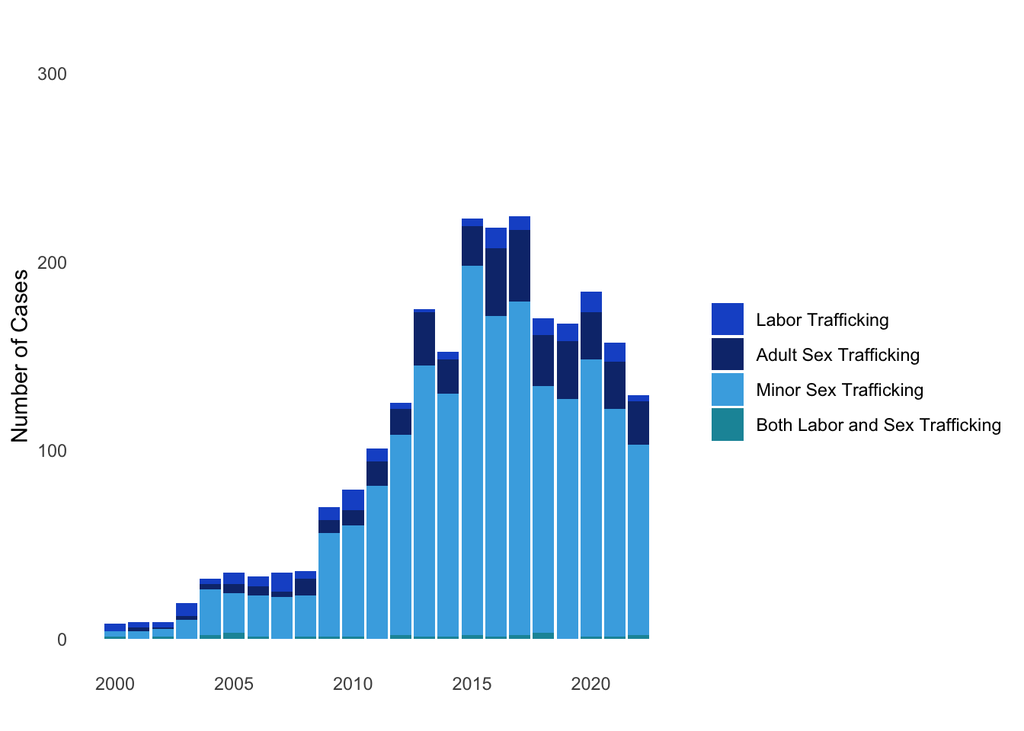

```r
one <- ggplot(data = na.omit(dta3), aes(x = (case_year), y = percent_of_total, fill = trafficking_type))+
  geom_bar(position = "stack", stat = "identity")+
  scale_fill_manual(values=(c("#1957CD", "#0F347B", "#46ADE3", "#1895A7" )))+
  ggtitle("") +
  theme_minimal() +
  xlab("") +
  ylim(0,300)+
  ylab("Number of Cases")+
  labs(fill = "")


one + theme(
  panel.grid.major = element_blank(),
  panel.grid.minor = element_blank(),
  plot.title = element_text(face = "bold", size = 12)
)
```

##Victim Summary Statistics

```r
#Number of Victims Per Case
range(as.numeric(allCase$case_number_victims), na.rm=TRUE)
```

```
## [1]   0 798
```

```r
#Number of Sting Operations
sum(as.numeric(allCase$case_number_victims) == 0, na.rm=TRUE)
```

```
## [1] 180
```

```r
#Number of Cases with Large number of Victims
sum(as.numeric(allCase$case_number_victims) >= 50, na.rm=TRUE)
```

```
## [1] 35
```

```r
#Trafficking Type as Predictor of Number of Victims
modVic <- lm(as.numeric(case_number_victims) ~ trafficking_type, data = allCase)
summary(modVic)
```

```
##
## Call:
## lm(formula = as.numeric(case_number_victims) ~ trafficking_type,
##     data = allCase)
##
## Residuals:
##    Min     1Q Median     3Q    Max
## -28.39  -2.11  -2.11  -0.11 769.61
##
## Coefficients:
##                                                Estimate Std. Error t value
## (Intercept)                                       6.478      1.496   4.331
## trafficking_typeBoth Sex and Labor Trafficking   -2.589      5.507  -0.470
## trafficking_typeLabor Trafficking                21.916      2.753   7.961
## trafficking_typeMinor Sex Trafficking            -3.370      1.626  -2.073
##                                                Pr(>|t|)
## (Intercept)                                    1.55e-05 ***
## trafficking_typeBoth Sex and Labor Trafficking   0.6383
## trafficking_typeLabor Trafficking              2.61e-15 ***
## trafficking_typeMinor Sex Trafficking            0.0383 *
## ---
## Signif. codes:  0 '***' 0.001 '**' 0.01 '*' 0.05 '.' 0.1 ' ' 1
##
## Residual standard error: 27.54 on 2370 degrees of freedom
##   (16 observations deleted due to missingness)
## Multiple R-squared:  0.04523,    Adjusted R-squared:  0.04402
## F-statistic: 37.42 on 3 and 2370 DF,  p-value: < 2.2e-16
```

```r
#Calculate Averages by Trafficking Type
dta <- allCase %>%
  group_by(trafficking_type)%>%
  summarize(
    avg = mean(as.numeric(case_number_victims), na.rm=TRUE)
  )
#view(dta)
```

##Victim Age Summary Statistics

```r
#Number of Victims by Age
minor <- sum(as.numeric(allCase$case_number_victims_minor), na.rm=TRUE)
print(minor)
```

```
## [1] 3436
```

```r
all <- sum(as.numeric(allCase$case_number_victims), na.rm=TRUE)
print(all)
```

```
## [1] 12132
```

```r
adult <- all-minor
print(adult)
```

```
## [1] 8696
```

```r
#Percent of Victims by age
8696/12132
```

```
## [1] 0.7167821
```

```r
3436/12132
```

```
## [1] 0.2832179
```

```r
# Looking at Victim Age Across Traff Type
# allCase <- allCase %>%
#   group_by(case_id) %>%
#   mutate(
#     any_minor = ifelse(coalesce(as.numeric(case_number_victims_minor), 0) > 0, 1, 0),
#     percent_minor = coalesce(as.numeric(case_number_victims_minor), 0) / coalesce(as.numeric(case_number_victims), 1)
#   )
#
# allCase$traff_m <- fct_relevel(allCase$trafficking_type, "Minor Sex Trafficking")
# mod_minor <- lm(percent_minor ~ traff_m, data=allCase)
# summary(mod_minor)

#Number of Victims by Case
dta <- allCase %>%
  group_by(trafficking_type) %>%
  summarise(
    any_minor = max(ifelse(as.numeric(case_number_victims_minor) > 0, 1, 0), na.rm = TRUE),
    total_minors = sum(as.numeric(case_number_victims_minor), na.rm = TRUE),
    all = sum(as.numeric(case_number_victims), na.rm = TRUE),
    adult = all - total_minors,
    percent_minor = ifelse(all > 0, total_minors / all * 100, 0)
  )
#view(dta)
```

##Vicitim Age by Trafficking Type - Format Data

```r
table(allCase$trafficking_type)
```

```
##
##          Adult Sex Trafficking Both Sex and Labor Trafficking
##                            344                             27
##              Labor Trafficking          Minor Sex Trafficking
##                            143                           1876
```

```r
dta <- allCase %>%
  group_by(trafficking_type)%>%
  summarise(
    count = sum(as.numeric(case_number_victims),na.rm = TRUE),
    count_m = sum(as.numeric(case_number_victims_minor),na.rm = TRUE),
    count_a = count - count_m,
   `Adult Victim` = count_a/count*100,
    `Minor Victim` = count_m/count*100
  )
dta$total<-  dta$`Adult Victim` + dta$ `Minor Victim`

dta2<-subset(dta, select=c("trafficking_type", "total", "Adult Victim",
                           "Minor Victim"))


dta3 <-melt(dta2, id.vars = c("trafficking_type", "total"), variable.name = "victim_type", value.name = "percent_of_victim")

#view(dta3)
```

##Figure 3 -Create Stacked Bar Chart of Trafficking Type

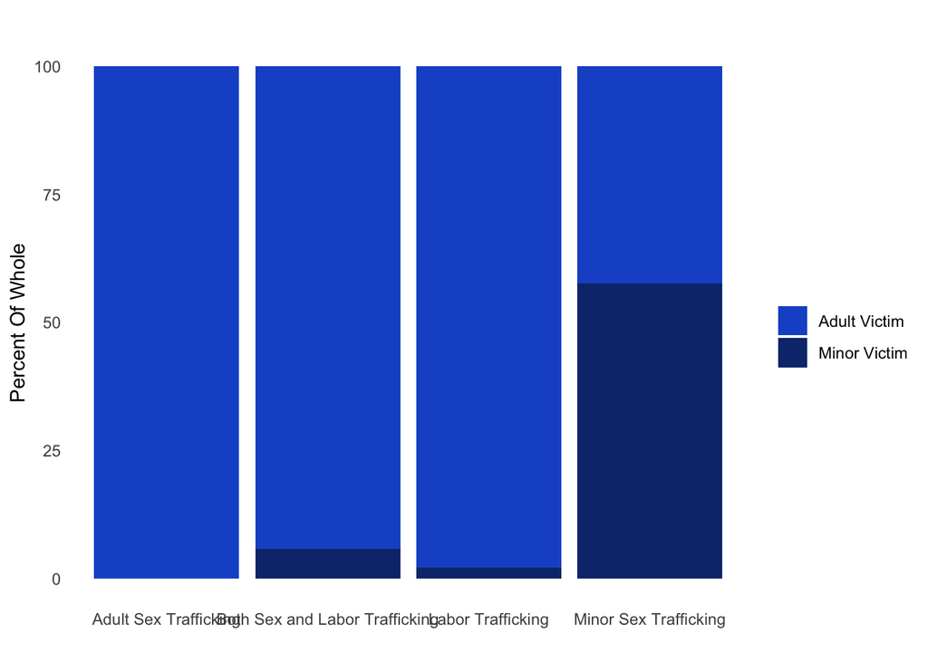

```r
three <- ggplot(data = dta3, aes(x = trafficking_type, y = percent_of_victim, fill = victim_type))+
  geom_bar(position = "stack", stat = "identity")+
  scale_fill_manual(values=(c("#1957CD", "#0F347B" )))+
  ggtitle("") +
  theme_minimal() +
  xlab("") +
  ylab("Percent Of Whole")+
  labs(fill = "")


three + theme(
  panel.grid.major = element_blank(),
  panel.grid.minor = element_blank(),
  plot.title = element_text(face = "bold", size = 12)
)
```

##Victim Gender Summary Statistics

```r
library(stargazer)
#Victim Age Summary
sortedGenderAll <- allCase %>%
  summarise(
    count_male = sum(as.numeric(case_number_victims_male), na.rm = TRUE),
    count_female = sum(as.numeric(case_number_victims_female), na.rm = TRUE),
    total_victims = sum(as.numeric(case_number_victims), na.rm=TRUE),
    percent_male = ifelse(total_victims > 0, (count_male / total_victims) * 100, NA),
    percent_female = ifelse(total_victims > 0, (count_female / total_victims) * 100, NA),
    anyMale = ifelse(count_male >= 1, 1, 0),
    sex_labor2 = ifelse(sex_labor == 1,0,1)
  )
#view(sortedGenderAll)

#note: This tidle includes the information for footnote 20
#Victim Gender across Trafficking Type
sortedGenderTraff <- allCase %>%
  group_by(trafficking_type)%>%
  summarise(
    count_male = sum(as.numeric(case_number_victims_male), na.rm = TRUE),
    count_unknown = sum(as.numeric(case_number_victims_unknown),na.rm=TRUE),
    count_female = sum(as.numeric(case_number_victims_female), na.rm = TRUE),
    total_victims = sum(as.numeric(case_number_victims), na.rm=TRUE),
    percent_male = ifelse(total_victims > 0, (count_male / total_victims) * 100, NA),
    percent_female = ifelse(total_victims > 0, (count_female / total_victims) * 100, NA),
    percent_unknown = ifelse(total_victims > 0, (count_unknown / total_victims) * 100, NA),
    anyMale = ifelse(count_male >= 1, 1, 0)
  )
#view(sortedGenderTraff)
table(sortedGenderAll$sex_labor2)
```

```
##
##    0    1
## 2182  142
```

```r
#Model Likelihood of having a male victim
sortedGenderAll <- allCase %>%
  group_by(case_id)%>%
  mutate(
    count_male = sum(as.numeric(case_number_victims_male), na.rm = TRUE),
    count_female = sum(as.numeric(case_number_victims_female), na.rm = TRUE),
    total_victims = sum(as.numeric(case_number_victims), na.rm=TRUE),
    percent_male = ifelse(total_victims > 0, (count_male / total_victims) * 100, NA),
    percent_female = ifelse(total_victims > 0, (count_female / total_victims) * 100, NA),
    anyMale = ifelse(count_male >= 1, 1, 0),
    sex_labor2 = ifelse(sex_labor == 1,0,1)
  )
mod_gender <- glm(anyMale ~ sex_labor2, data = sortedGenderAll, family = binomial() )
stargazer(mod_gender, type="text")
```

```
##
## =============================================
##                       Dependent variable:
##                   ---------------------------
##                             anyMale
## ---------------------------------------------
## sex_labor2                 2.900***
##                             (0.244)
##
## Constant                   -3.907***
##                             (0.154)
##
## ---------------------------------------------
## Observations                 2,324
## Log Likelihood             -293.908
## Akaike Inf. Crit.           591.817
## =============================================
## Note:             *p<0.1; **p<0.05; ***p<0.01
```

```r
#Number of victims with unknown Gender
sum(as.numeric(allCase$case_number_victims_unknown),na.rm=TRUE)
```

```
## [1] 4222
```

##Victim Gender - Format Data

```r
dta <- allCase %>%
  group_by(trafficking_type) %>%
  summarise(
    count_f = sum(as.numeric(case_number_victims_female), na.rm = TRUE),
    total_victims = sum(as.numeric(case_number_victims), na.rm = TRUE),
    count_m = total_victims - count_f,
    `Female Victim` = count_f / total_victims * 100,
    `Male Victim` = count_m / total_victims * 100
  )
dta$total<-  dta$`Female Victim` + dta$`Male Victim`

dta2<-subset(dta, select=c("trafficking_type", "total", "Male Victim",
                           "Female Victim"))


dta3 <-melt(dta2, id.vars = c("trafficking_type", "total"), variable.name = "victim_type", value.name = "percent_of_victim")
```

##Figure 4 - Stacked Bar chart of Victim Gender

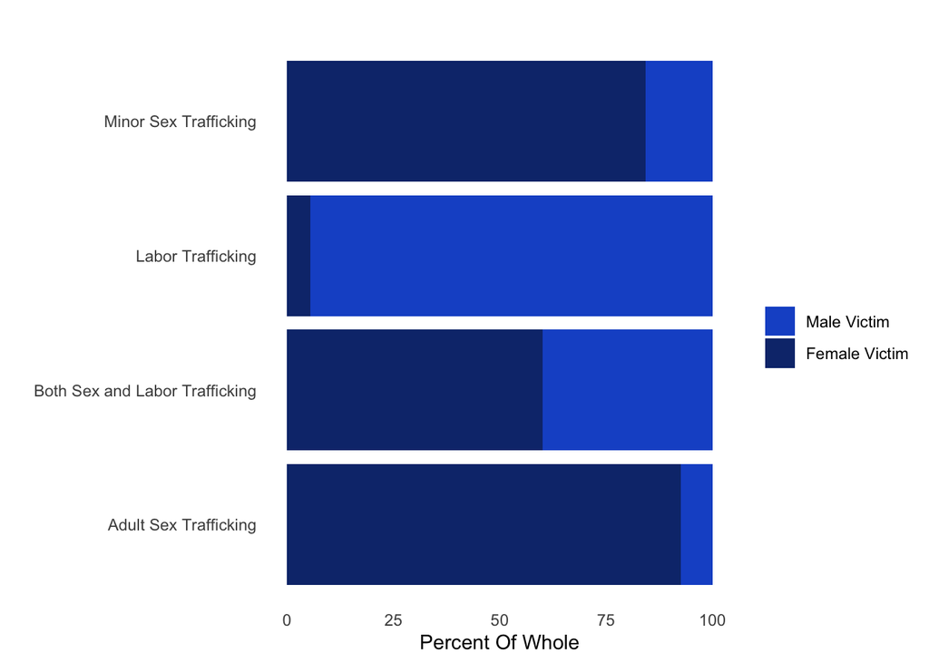

```r
four <- ggplot(data = dta3, aes(x = trafficking_type, y = percent_of_victim, fill = victim_type))+
  geom_bar(position = "stack", stat = "identity")+
  scale_fill_manual(values=(c("#1957CD", "#0F347B" )))+
  ggtitle("") +
  theme_minimal() +
  xlab("") +
  ylab("Percent Of Whole")+
  labs(fill = "")+
  coord_flip()


four + theme(
  panel.grid.major = element_blank(),
  panel.grid.minor = element_blank(),
  plot.title = element_text(face = "bold", size = 12)
)
```

##Foreign National Victim Summary Statistics

```r
#Number of Foreign Victims
sum(as.numeric(allCase$case_number_victims_foreign), na.rm = TRUE)
```

```
## [1] 6612
```

```r
#Percentage of Foreign versus not Foreign Victims
6612/12132
```

```
## [1] 0.5450049
```

```r
282/12132
```

```
## [1] 0.02324431
```

```r
#Number of Cases with Foreign Victims
dta2 <- allCase %>%
    summarise(
      hasForeign = sum(as.numeric(case_number_victims_foreign)>0, na.rm=TRUE),
      total = n(),
      percent = hasForeign/total
    )
#view(dta2)


#Number of Forg/Non-Forg victims by Trafficking Type
dta3 <- allCase %>%
  group_by(trafficking_type)%>%
    summarise(
      foreign = sum(as.numeric(case_number_victims_foreign), na.rm = TRUE),
      count_total = sum(as.numeric(case_number_victims),na.rm = TRUE),
      percent = foreign/count_total
    )
#view(dta)

#OLS Model of Likiehood of having Foreign Victims by Trafficking Type
dta4 <- allCase %>%
  group_by(case_id)%>%
    mutate(
      hasForeign = sum(as.numeric(case_number_victims_foreign)>0, na.rm=TRUE),
      total = n(),
      percent = hasForeign/total
    )
mod_forg <- glm(hasForeign ~ trafficking_type, data = dta4, family = binomial())
summary(mod_forg)
```

```
##
## Call:
## glm(formula = hasForeign ~ trafficking_type, family = binomial(),
##     data = dta4)
##
## Coefficients:
##                                                Estimate Std. Error z value
## (Intercept)                                     -1.5346     0.1412 -10.871
## trafficking_typeBoth Sex and Labor Trafficking   1.4605     0.4102   3.560
## trafficking_typeLabor Trafficking                3.3510     0.2794  11.994
## trafficking_typeMinor Sex Trafficking           -1.5133     0.1796  -8.427
##                                                Pr(>|z|)
## (Intercept)                                     < 2e-16 ***
## trafficking_typeBoth Sex and Labor Trafficking 0.000371 ***
## trafficking_typeLabor Trafficking               < 2e-16 ***
## trafficking_typeMinor Sex Trafficking           < 2e-16 ***
## ---
## Signif. codes:  0 '***' 0.001 '**' 0.01 '*' 0.05 '.' 0.1 ' ' 1
##
## (Dispersion parameter for binomial family taken to be 1)
##
##     Null deviance: 1734.7  on 2389  degrees of freedom
## Residual deviance: 1166.8  on 2386  degrees of freedom
## AIC: 1174.8
##
## Number of Fisher Scoring iterations: 5
```

##Victim Nationality - Format Data

```r
library(reshape2)
dta <- allCase %>%
  group_by(trafficking_type)%>%
  summarise(
    count = sum(as.numeric(case_number_victims),na.rm = TRUE),
    count_f = sum(as.numeric(case_number_victims_foreign),na.rm = TRUE),
    count_us = count - count_f,
   `Foreign National` = count_f/count*100,
    `US National` = count_us/count*100
  )
dta$total<-  dta$`Foreign National` + dta$ `US National`

dta2<-subset(dta, select=c("trafficking_type", "total", "Foreign National",
                           "US National"))


dta3 <-melt(dta2, id.vars = c("trafficking_type", "total"), variable.name = "victim_type", value.name = "percent_of_victim")
```

##Figure 5 - Victim Nationality

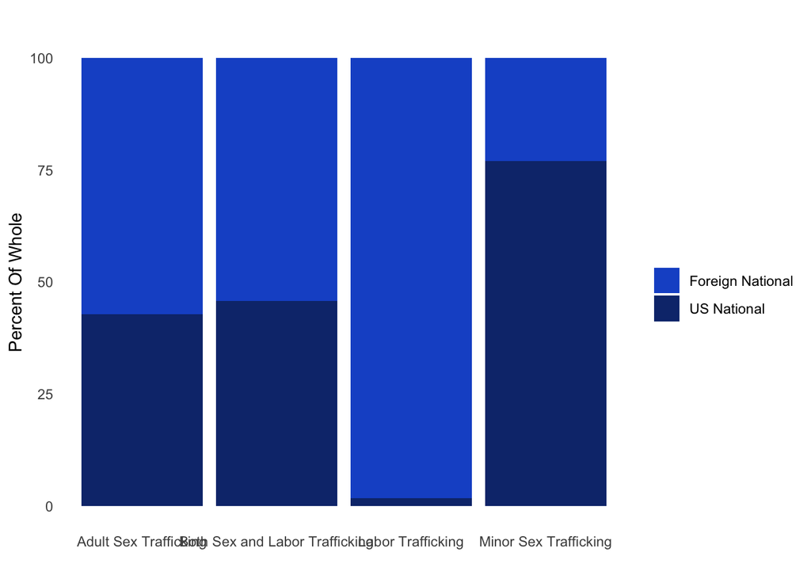

```r
three <- ggplot(data = dta3, aes(x = trafficking_type, y = percent_of_victim, fill = victim_type))+
  geom_bar(position = "stack", stat = "identity")+
  scale_fill_manual(values=(c("#1957CD", "#0F347B" )))+
  ggtitle("") +
  theme_minimal() +
  xlab("") +
  ylab("Percent Of Whole")+
  labs(fill = "")


three + theme(
  panel.grid.major = element_blank(),
  panel.grid.minor = element_blank(),
  plot.title = element_text(face = "bold", size = 12)
)
```

##Time Series for Victims

```r
#Number of Victims Over Time
mod_time_total <- lm(as.numeric(case_number_victims) ~ case_year, data=allCase)
summary(mod_time_total)
```

```
##
## Call:
## lm(formula = as.numeric(case_number_victims) ~ case_year, data = allCase)
##
## Residuals:
##    Min     1Q Median     3Q    Max
## -16.28  -5.06  -2.46   0.35 787.93
##
## Coefficients:
##              Estimate Std. Error t value Pr(>|t|)
## (Intercept) 1619.8440   249.6753   6.488 1.06e-10 ***
## case_year     -0.8013     0.1239  -6.467 1.21e-10 ***
## ---
## Signif. codes:  0 '***' 0.001 '**' 0.01 '*' 0.05 '.' 0.1 ' ' 1
##
## Residual standard error: 27.93 on 2372 degrees of freedom
##   (16 observations deleted due to missingness)
## Multiple R-squared:  0.01733,    Adjusted R-squared:  0.01691
## F-statistic: 41.83 on 1 and 2372 DF,  p-value: 1.207e-10
```

```r
#Number of Minors over time

dta2 <- allCase %>%
  group_by(case_id) %>%
  mutate(
    total_m= sum(as.numeric(case_number_victims_minor, na.rm = TRUE)),
    total = sum(as.numeric(case_number_victims, na.rm = TRUE)),
    percent = total_m / total
  )
mod_time_minor <- lm(percent ~ case_year, data=dta2)
summary(mod_time_minor)
```

```
##
## Call:
## lm(formula = percent ~ case_year, data = dta2)
##
## Residuals:
##     Min      1Q  Median      3Q     Max
## -0.7499 -0.4660  0.2709  0.3229  2.3437
##
## Coefficients:
##               Estimate Std. Error t value Pr(>|t|)
## (Intercept) -20.272656   3.997443  -5.071 4.28e-07 ***
## case_year     0.010397   0.001984   5.241 1.75e-07 ***
## ---
## Signif. codes:  0 '***' 0.001 '**' 0.01 '*' 0.05 '.' 0.1 ' ' 1
##
## Residual standard error: 0.4299 on 2189 degrees of freedom
##   (199 observations deleted due to missingness)
## Multiple R-squared:  0.01239,    Adjusted R-squared:  0.01194
## F-statistic: 27.47 on 1 and 2189 DF,  p-value: 1.751e-07
```

```r
#Percent of Cases with any Minor Over Time
allCase$minor_binary <- ifelse(allCase$case_number_victims_minor > 0,1,0)
table(allCase$minor_binary)
```

```
##
##    0    1
##  664 1726
```

```r
dta2 <- allCase %>%
  group_by(case_year) %>%
  summarise(
    total_w_m = sum(minor_binary, na.rm = TRUE),
    total = n(),
    percent = total_w_m / total
  ) %>%
  ungroup()

mod_time_minor_percent <- lm(percent ~ case_year, data = dta2)
summary(mod_time_minor_percent)
```

```
##
## Call:
## lm(formula = percent ~ case_year, data = dta2)
##
## Residuals:
##       Min        1Q    Median        3Q       Max
## -0.149384 -0.060094  0.001407  0.052303  0.157733
##
## Coefficients:
##               Estimate Std. Error t value Pr(>|t|)
## (Intercept) -17.111566   5.446930  -3.142  0.00493 **
## case_year     0.008844   0.002709   3.265  0.00370 **
## ---
## Signif. codes:  0 '***' 0.001 '**' 0.01 '*' 0.05 '.' 0.1 ' ' 1
##
## Residual standard error: 0.08616 on 21 degrees of freedom
## Multiple R-squared:  0.3367, Adjusted R-squared:  0.3051
## F-statistic: 10.66 on 1 and 21 DF,  p-value: 0.003699
```

```r
#Gender Over Time
allCase$male_binary <- ifelse(as.numeric(allCase$case_number_victims_male) > 0,1,0)
table(allCase$male_binary)
```

```
##
##    0    1
## 2272   84
```

```r
dta3 <- allCase %>%
  group_by(case_year) %>%
  summarise(
    total_m = sum((male_binary), na.rm=TRUE),
    total = n(),
    percent = total_m / total ,
    year = as.numeric(case_year),
    sex_labor2 = as.numeric(sex_labor)
  ) %>%
  ungroup()
mod_time_male_percent <- lm(percent ~ case_year, data = dta3)
summary(mod_time_male_percent)
```

```
##
## Call:
## lm(formula = percent ~ case_year, data = dta3)
##
## Residuals:
##       Min        1Q    Median        3Q       Max
## -0.032735 -0.025909 -0.003815  0.014985  0.192617
##
## Coefficients:
##               Estimate Std. Error t value Pr(>|t|)
## (Intercept) -0.7531940  0.2868224  -2.626  0.00869 **
## case_year    0.0003912  0.0001423   2.749  0.00603 **
## ---
## Signif. codes:  0 '***' 0.001 '**' 0.01 '*' 0.05 '.' 0.1 ' ' 1
##
## Residual standard error: 0.03239 on 2388 degrees of freedom
## Multiple R-squared:  0.003154,   Adjusted R-squared:  0.002736
## F-statistic: 7.554 on 1 and 2388 DF,  p-value: 0.006031
```

```r
#Cases with Any Male Over Time
dta4 <- allCase %>%
  filter(trafficking_type != "Labor Trafficking")%>%
  group_by(case_year) %>%
  summarise(
    total_m = sum(as.numeric(case_number_victims_male), na.rm = TRUE),
    total = sum(as.numeric(case_number_victims), na.rm = TRUE),
    percent = (total_m+1) / (total+1) ,
    year = as.numeric(case_year)
  ) %>%
  ungroup()
view(dta4)

mod_time_male <- lm(percent ~ year, data = dta4)
summary(mod_time_male)
```

```
##
## Call:
## lm(formula = percent ~ year, data = dta4)
##
## Residuals:
##      Min       1Q   Median       3Q      Max
## -0.03171 -0.02048 -0.00837  0.00131  0.41571
##
## Coefficients:
##               Estimate Std. Error t value Pr(>|t|)
## (Intercept) -3.5641986  0.4681028  -7.614 3.88e-14 ***
## year         0.0017832  0.0002323   7.677 2.41e-14 ***
## ---
## Signif. codes:  0 '***' 0.001 '**' 0.01 '*' 0.05 '.' 0.1 ' ' 1
##
## Residual standard error: 0.04908 on 2245 degrees of freedom
## Multiple R-squared:  0.02558,    Adjusted R-squared:  0.02515
## F-statistic: 58.94 on 1 and 2245 DF,  p-value: 2.41e-14
```

```r
#Cases with Foreign Victims over Time
dta5 <- lightHouse%>%
  group_by(case_year)%>%
  mutate(
    total = n(),
    totalNoUS = sum(def_forg_binary == 0),
    forgNat = (totalNoUS)/total
  )%>%
  ungroup()

mod_time_forg <- lm(forgNat ~ case_year, data = dta5)
summary(mod_time_forg)
```

```
##
## Call:
## lm(formula = forgNat ~ case_year, data = dta5)
##
## Residuals:
##      Min       1Q   Median       3Q      Max
## -0.16442 -0.04562 -0.01738  0.04024  0.25574
##
## Coefficients:
##               Estimate Std. Error t value Pr(>|t|)
## (Intercept) 49.5252644  0.4735110   104.6   <2e-16 ***
## case_year   -0.0244412  0.0002351  -104.0   <2e-16 ***
## ---
## Signif. codes:  0 '***' 0.001 '**' 0.01 '*' 0.05 '.' 0.1 ' ' 1
##
## Residual standard error: 0.08297 on 4582 degrees of freedom
## Multiple R-squared:  0.7022, Adjusted R-squared:  0.7022
## F-statistic: 1.081e+04 on 1 and 4582 DF,  p-value: < 2.2e-16
```

##Trafficking Location Summary Statistics

```r
#Total Crime Locations
nrow(allCrime)
```

```
## [1] 5743
```

```r
#Total County Locations
sum((allCrime$crime_location_county != "Unlisted" ),na.rm=TRUE)
```

```
## [1] 3909
```

```r
#Total City Locations
sum(allCrime$crime_location_city != "Unlisted")
```

```
## [1] 3608
```

```r
#Looking at Top Counties
top_10_counties <- c("Los Angeles", "Cook", "Harris", "Maricopa", "San Diego",
                     "Orange", "Miami-Dade", "Dallas", "Kings", "Riverside")

table(allCrime$crime_location_county)
```

[output not shown]

[output cut: 268 more lines]

[output not shown]

```r
637/3909
```

```
## [1] 0.1629573
```

```r
#Create Measure of if Crime was in Top 10 County
allCrime$crime_location_county <- ifelse(allCrime$crime_location_county == "Unlisted", NA, allCrime$crime_location_county)
allCrime$big_county_binary <- ifelse(is.na(allCrime$crime_location_county), NA, ifelse(allCrime$crime_location_county %in% top_10_counties, 1, 0))


table(allCrime$big_county_binary)
```

```
##
##    0    1
## 3274  635
```

```r
dta <- allCrime %>%
  group_by(crime_location_county)%>%
  mutate(
    count = n()
  )

#Likelihood of Crime being in a Big County
mod_big_county <- lm(count ~ big_county_binary, data = dta)
stargazer(mod_big_county, type = "text")
```

```
##
## ===============================================
##                         Dependent variable:
##                     ---------------------------
##                                count
## -----------------------------------------------
## big_county_binary            56.673***
##                               (1.101)
##
## Constant                     25.782***
##                               (0.444)
##
## -----------------------------------------------
## Observations                   3,909
## R2                             0.404
## Adjusted R2                    0.404
## Residual Std. Error     25.391 (df = 3907)
## F Statistic         2,649.637*** (df = 1; 3907)
## ===============================================
## Note:               *p<0.1; **p<0.05; ***p<0.01
```

```r
#Top Counties
dta <- allCrime %>%
  group_by(crime_location_county)%>%
  summarise(
    count = n()
  )
#view(dta)

#Count Top Cities
dta <- allCrime %>%
  group_by(crime_location_city)%>%
  summarise(
    count = n()
  )
#view(dta)
```

#Defendant Level Data

##Defendant Summary Stats

```r
#As noted above - 'lightHouse' is the dataset that contains defendant level data, the dataset is named after Allies data aggregation and visualization tool which houses FCD - when case level data is needed (to look at defendants in aggregate, allCase is used)

#Number of Defendants
nrow(lightHouse)
```

```
## [1] 4584
```

```r
#Number of Defendants Per Case Over Time
mod_def_time <- lm(case_number_defendants ~ case_year, data = allCase)
summary(mod_def_time)
```

```
##
## Call:
## lm(formula = case_number_defendants ~ case_year, data = allCase)
##
## Residuals:
##    Min     1Q Median     3Q    Max
## -2.377 -0.939 -0.496 -0.045 36.619
##
## Coefficients:
##              Estimate Std. Error t value Pr(>|t|)
## (Intercept) 224.86425   22.67401   9.917   <2e-16 ***
## case_year    -0.11063    0.01125  -9.833   <2e-16 ***
## ---
## Signif. codes:  0 '***' 0.001 '**' 0.01 '*' 0.05 '.' 0.1 ' ' 1
##
## Residual standard error: 2.56 on 2388 degrees of freedom
## Multiple R-squared:  0.03891,    Adjusted R-squared:  0.03851
## F-statistic: 96.68 on 1 and 2388 DF,  p-value: < 2.2e-16
```

```r
#Number of Defendants Across Trafficking Type
dta <- allCase %>%
  group_by(trafficking_type)%>%
  summarise(
    avg= mean(case_number_defendants)
  )

view(dta)
```

##Defendant Race Summary Statistics

```r
library(plm)

#Summarizing Race
dta <- lightHouse %>%
  summarise(
    count_black = sum(defendants_race == "Black", na.rm = TRUE),
    count_asian = sum(defendants_race == "Asian", na.rm = TRUE),
    count_white = sum(defendants_race == "White", na.rm = TRUE),
    count_other = sum(defendants_race == "Other", na.rm = TRUE),
    count_hispanic = sum((defendants_race == "Hispanic"),na.rm = TRUE),
    count_unknown = 4584 - count_asian -count_black-count_white-count_other - count_hispanic,
    total_count = n(),  # Total number of defendants
    Black = count_black / total_count * 100,  # Percentage of Black defendants
    Asian = count_asian / total_count * 100,  # Percentage of Asian defendants
    White = count_white / total_count * 100,  # Percentage of White defendants
    Other = (count_other+count_unknown) / total_count * 100 ,
    Hispanic = count_hispanic/total_count * 100# Percentage of Other defendants
  )
#view(dta)

dta <- lightHouse %>%
  group_by(case_year)%>%
  summarise(
    count_black = sum(defendants_race == "Black", na.rm = TRUE),
    count_asian = sum(defendants_race == "Asian", na.rm = TRUE),
    count_white = sum(defendants_race == "White", na.rm = TRUE),
    count_other = sum(defendants_race == "Other", na.rm = TRUE),
    count_hispanic = sum((defendants_race == "Hispanic"),na.rm = TRUE),
    count_unknown = 4584 - count_asian -count_black-count_white-count_other - count_hispanic,
    total_count = n(),
    Black = count_black / total_count * 100,
    Asian = count_asian / total_count * 100,
    White = count_white / total_count * 100,
    Other = (count_other+count_unknown) / total_count * 100 ,
    Hispanic = count_hispanic/total_count * 100
  )

#Modeling Race over Time
lightHouse$defendants_race <- fct_relevel(lightHouse$defendants_race, "White")

dta <- lightHouse %>%
  group_by(defendants_race, case_year) %>%
  summarise(
    count = n(),
    .groups = 'drop'
  )

# Group by year to calculate the total counts for each year
year_totals <- dta %>%
  group_by(case_year) %>%
  summarise(
    total_count = sum(count),
    .groups = 'drop'
  )

# Join the year_totals with the original data and calculate the percent for each clean_sex by year
dta2 <- dta %>%
  left_join(year_totals, by = "case_year") %>%
  mutate(
    percentYear = count / total_count * 100
  )

#view(dta2)

#Fixed Effect Model of Mean Variation by Year
mod4 <- plm(percentYear ~ defendants_race, index = "case_year", data = na.omit(dta2))
stargazer(mod4, type = "text")
```

```
##
## ===================================================
##                             Dependent variable:
##                         ---------------------------
##                                 percentYear
## ---------------------------------------------------
## defendants_raceAsian            -11.757***
##                                   (3.846)
##
## defendants_raceBlack             19.956***
##                                   (3.846)
##
## defendants_raceHispanic           -0.214
##                                   (3.846)
##
## defendants_raceOther            -17.306***
##                                   (4.021)
##
## ---------------------------------------------------
## Observations                        111
## R2                                 0.563
## Adjusted R2                        0.428
## F Statistic               27.102*** (df = 4; 84)
## ===================================================
## Note:                   *p<0.1; **p<0.05; ***p<0.01
```

```r
#Looking at Sex and Labor trafficking distributions of hispanic defendants

dta <- lightHouse %>%
  group_by(trafficking_type.x)%>%
  summarise(
    count_hispanic = sum((defendants_race == "Hispanic"),na.rm = TRUE),
    total_count = n(),
    Hispanic = count_hispanic/total_count * 100
  )
#view(dta)

#OLS Model of Sex versys Labor Trafficking distribution of Black Defendants
dta <- lightHouse %>%
  summarise(
    count_black = sum((defendants_race == "Black"),na.rm = TRUE),
    total_count = n(),
    Black = count_black/total_count * 100
  )
view(dta)

#Black Defendants Across State
#States used to remove territories
states = c("AL", "AK", "AZ", "AR", "CA", "CO", "CT", "DE", "FL", "GA",
                 "HI", "ID", "IL", "IN", "IA", "KS", "KY", "LA", "ME", "MD",
                 "MA", "MI", "MN", "MS", "MO", "MT", "NE", "NV", "NH", "NJ",
                 "NM", "NY", "NC", "ND", "OH", "OK", "OR", "PA", "RI", "SC",
                 "SD", "TN", "TX", "UT", "VT", "VA", "WA", "WV", "WI", "WY")

table(lightHouse$state_prosecuted)
```

```
##
##  AK  AL  AR  AZ  CA  CO  CT  DC  DE  FL  GA  GU  HI  IA  ID  IL  IN  KS  KY  LA
##  23  19  40  49 523   6  40  33   2 340 217   4  26  46   7  95  57  59  24  49
##  MA  MD  ME  MI  MN  MO  MP  MS  MT  NC  ND  NE  NH  NJ  NM  NV  NY  OH  OK  OR
##  84 120   8 112  81 120   4  19  13  68  40  23   6  75  30  43 441 118  68  55
##  PA  PR  RI  SC  SD  TN  TX  UT  VA  VI  VT  WA  WI  WV
## 178  28  21  70  72 111 499  24 209   3  18  78  71  15
```

```r
dta <- lightHouse %>%
  filter(state_prosecuted %in% states)%>%
  group_by(state_prosecuted)%>%
  summarise(
    count_black = sum(defendants_race == "Black", na.rm = TRUE),
    count_asian = sum(defendants_race == "Asian", na.rm = TRUE),
    count_white = sum(defendants_race == "White", na.rm = TRUE),
    count_other = sum(defendants_race == "Other", na.rm = TRUE),
    count_hispanic = sum((defendants_race == "Hispanic"),na.rm = TRUE),
    count_unknown = 4584 - count_asian -count_black-count_white-count_other - count_hispanic,
    total_count = n(),
    Black = count_black / total_count * 100,
    Asian = count_asian / total_count * 100,
    White = count_white / total_count * 100,
    Other = (count_other+count_unknown) / total_count * 100 ,
    Hispanic = count_hispanic/total_count * 100,
    black_most_prosecuted = ifelse(Black > White, 1,
      ifelse(Black > Asian,1,
             ifelse(Black > Other,1, 0)))
    )


table(dta$black_most_prosecuted)
```

```
##
##  0  1
##  2 47
```

```r
view(dta)

#Black Defendants Across Trafficking Type
dta <- lightHouse %>%
  group_by(trafficking_type.x)%>%
  summarise(
    count_black = sum((defendants_race == "Black"),na.rm = TRUE),
    total_count = n(),
    Black = count_black/total_count * 100
  )
view(dta)
```

##Defendant Race - Format Data

```r
library(nnet)
library(stargazer)
library(margins)
library(effects)
library(tidyverse)
library(reshape2)

table(lightHouse$defendants_race)
```

```
##
##    White    Asian    Black Hispanic    Other
##      927      281     2108      732       82
```

```r
dta <- lightHouse %>%
  group_by(trafficking_type.x)%>%
  summarise(
    count_black = sum((defendants_race == "Black"),na.rm = TRUE),
    count_asian = sum((defendants_race == "Asian"),na.rm = TRUE),
    count_white = sum((defendants_race == "White"),na.rm = TRUE),
    count_other = sum((defendants_race == "Other"),na.rm = TRUE),
    count_hispanic = sum((defendants_race == "Hispanic"),na.rm = TRUE),
    count = count_black +count_asian+count_white+count_other+count_hispanic,
    Black = count_black/count*100,
    Asian = count_asian/count*100,
    Other = count_white/count*100,
    White= count_other/count*100,
    Hispanic = count_hispanic/count*100
  )


dta$total<-  dta$Black + dta$Asian + dta$Hispanic + dta$White+dta$Other

dta2<-subset(dta, select=c("trafficking_type.x", "total",
                           "Asian", "Black", "Other","Hispanic", "White" ))


dta3 <-melt(dta2, id.vars = c("trafficking_type.x", "total"), variable.name = "victim_type", value.name = "percent_of_victim")
```

##Figure 7 - Race by Trafficking Type

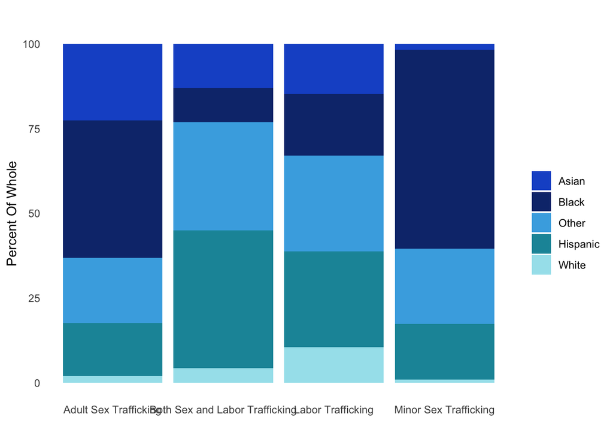

```r
seven <- ggplot(data = dta3, aes(x = trafficking_type.x, y = percent_of_victim, fill = victim_type))+
  geom_bar(position = "stack", stat = "identity")+
  scale_fill_manual(values=(c("#1957CD", "#0F347B", "#46ADE3", "#1895A7","#A5E3ED" )))+
  ggtitle("") +
  theme_minimal() +
  xlab("") +
  ylab("Percent Of Whole")+
  labs(fill = "")


seven + theme(
  panel.grid.major = element_blank(),
  panel.grid.minor = element_blank(),
  plot.title = element_text(face = "bold", size = 12)
)
```

##Defendant Age Summary Statistics

```r
#Average and Range of Age
mean(as.numeric(lightHouse$defendants_arrest_age),na.rm=TRUE)
```

```
## [1] 33.65625
```

```r
range(as.numeric(lightHouse$defendants_arrest_age),na.rm=TRUE)
```

```
## [1] 17 90
```

```r
#OLS model of age by sex versus labor
mod_age_traff <- lm(defendants_arrest_age ~ sex_labor, data =lightHouse)
summary(mod_age_traff)
```

```
##
## Call:
## lm(formula = defendants_arrest_age ~ sex_labor, data = lightHouse)
##
## Residuals:
##     Min      1Q  Median      3Q     Max
## -24.062  -8.742  -2.742   6.258  57.258
##
## Coefficients:
##             Estimate Std. Error t value Pr(>|t|)
## (Intercept)  42.0623     0.6197   67.87   <2e-16 ***
## sex_labor    -9.3202     0.6477  -14.39   <2e-16 ***
## ---
## Signif. codes:  0 '***' 0.001 '**' 0.01 '*' 0.05 '.' 0.1 ' ' 1
##
## Residual standard error: 11.1 on 3793 degrees of freedom
##   (789 observations deleted due to missingness)
## Multiple R-squared:  0.05176,    Adjusted R-squared:  0.05151
## F-statistic:   207 on 1 and 3793 DF,  p-value: < 2.2e-16
```

```r
#avg. age across trafficking type
dta <- lightHouse %>%
  group_by(trafficking_type.x)%>%
  summarise(
    avg = mean(as.numeric(defendants_arrest_age),na.rm=TRUE)
  )

view(dta)
```

##Defendant Age - Format Data

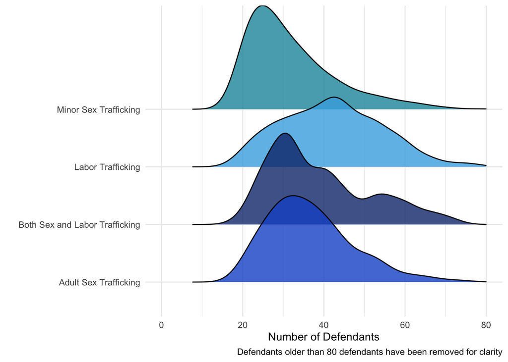

```r
library(ggridges)

ggplot(data = lightHouse, aes(x = defendants_arrest_age, y = trafficking_type.x, fill = trafficking_type.x)) +
  geom_density_ridges(alpha = 0.8) +
  xlim(0,80)+
  labs(
    y = "",
    x = "Number of Defendants",
    color = "Type of Trafficking",
    caption = "Defendants older than 80 defendants have been removed for clarity"
  ) +
  scale_fill_manual(values=(c("#1957CD", "#0F347B", "#46ADE3", "#1895A7" )))+
  theme_minimal() +
  theme(legend.position = "none")
```

```r
dta <- lightHouse %>%
  group_by(trafficking_type.x)%>%
  summarise(
    count_m = sum((gender_binary ==1),na.rm = TRUE),
    count_f = sum((gender_binary ==0),na.rm = TRUE),
    count = count_m + count_f,
    Female = count_m/count*100,
    Male = count_f/count*100
  )


dta$total<-  dta$Female + dta$Male

dta2<-subset(dta, select=c("trafficking_type.x", "total", "Female",
                           "Male"))


dta3 <-melt(dta2, id.vars = c("trafficking_type.x", "total"), variable.name = "victim_type", value.name = "percent_of_victim")

view(dta3)
```

##Defendant Gender Summary Statistics

```r
table(lightHouse$defendants_gender)
```

```
##
##  Female    Male Unknown
##    1097    3425      62
```

```r
#Number Female
1097/4584
```

```
## [1] 0.2393106
```

```r
#Number Male
3425/4584
```

```
## [1] 0.747164
```

```r
#Number Unknown
62/4584
```

```
## [1] 0.01352531
```

```r
#Number Companies
13/4584
```

```
## [1] 0.002835951
```

```r
#Gender by Trafficking Type
dta <- lightHouse %>%
  group_by(trafficking_type.x)%>%
  summarise(
    count_m = sum((gender_binary ==1),na.rm = TRUE),
    count_f = sum((gender_binary ==0),na.rm = TRUE),
    count = count_m + count_f,
    Female = count_m/count*100,
    Male = count_f/count*100
  )

view(dta)
```

##Figure 9: Defendant Gender by Type of Trafficking

```r
#Violin Plot
allCase$case_number_victims_female
```

[output not shown]

[output cut: 224 more lines]

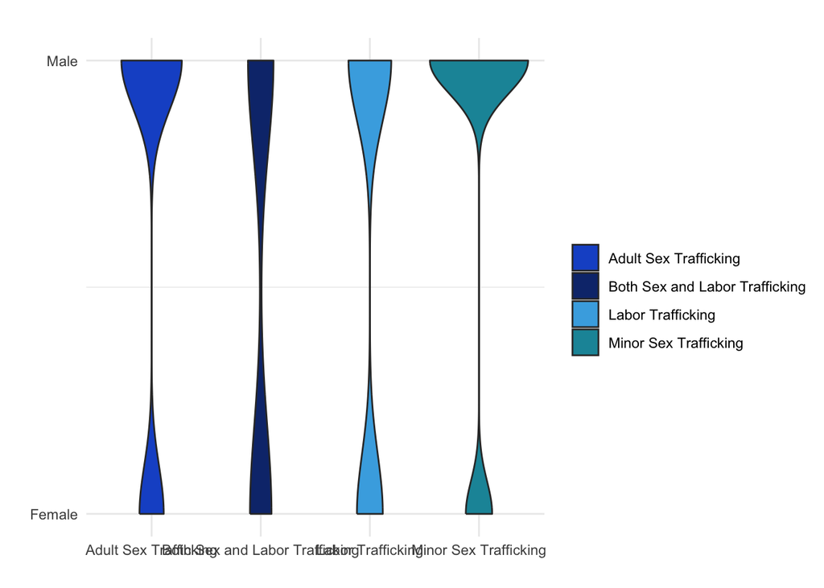

```r
ggplot(data = lightHouse, aes(x = trafficking_type.x, y = (1+gender_binary), fill = trafficking_type.x))+
  geom_violin()+
  scale_fill_manual(values=(c("#1957CD", "#0F347B", "#46ADE3", "#1895A7" )))+
  ggtitle("") +
  theme_minimal() +
  xlab("") +
  ylab("")+
  labs(fill = "")+
  scale_y_continuous(breaks = c(1, 2), labels = c("Female", "Male"))
```

##Foreign National Defendants Summary Statistics

```r
table(lightHouse$def_forg_binary)
```

```
##
##    0    1
## 1386 3198
```

```r
#Number of Foreign Defendants
1386/(1386+3198)
```

```
## [1] 0.302356
```

```r
#Number of US Defendants
3198/(1386+3198)
```

```
## [1] 0.697644
```

```r
#Foreign but Unknown Defendants
613/(1386+3198)
```

```
## [1] 0.133726
```

```r
#Top Countries of origin
dta <- lightHouse%>%
  group_by(defendants_country_of_origin)%>%
  summarise(
    total=n()
  )

#view(dta)

#Percent of Whole by Top Countries
251/4584
```

```
## [1] 0.05475567
```

```r
75/4584
```

```
## [1] 0.01636126
```

```r
38/4584
```

```
## [1] 0.008289703
```

```r
34/4584
```

```
## [1] 0.007417103
```

```r
32/4584
```

```
## [1] 0.006980803
```

##Defendant Nationality - Format Data

```r
table(allCase$trafficking_type)
```

```
##
##          Adult Sex Trafficking Both Sex and Labor Trafficking
##                            344                             27
##              Labor Trafficking          Minor Sex Trafficking
##                            143                           1876
```

```r
table(lightHouse$def_forg_binary)
```

```
##
##    0    1
## 1386 3198
```

```r
dta <- lightHouse %>%
  group_by(trafficking_type.x)%>%
  summarise(
    count_us = sum((def_forg_binary ==1),na.rm = TRUE),
    count_nonus = sum((def_forg_binary ==0),na.rm = TRUE),
    count = count_us + count_nonus,
   `US National` = count_us/count*100,
    `Other Nationality` = count_nonus/count*100
  )


dta$total<-  dta$`US National` + dta$`Other Nationality`

dta2<-subset(dta, select=c("trafficking_type.x", "total", "US National",
                           "Other Nationality"))


dta3 <-melt(dta2, id.vars = c("trafficking_type.x", "total"), variable.name = "victim_type", value.name = "percent_of_victim")

#view(dta3)
```

##Figure 10 - Create Stacked Bar Chart of Trafficking Type

```r
table(lightHouse$defendants_country_of_origin)
```

```
##
##                                                                 Aland Islands
##                                    613                                      1
##                         American Samoa                             Azerbaijan
##                                      2                                      1
##                                Belarus                                  Benin
##                                      3                                      1
##                 Bosnia and Herzegovina                                 Brazil
##                                      1                                      5
##                               Cameroon                                 Canada
##                                      7                                      2
##                                  China                               Colombia
##                                     32                                      6
##                             Costa Rica                                   Cuba
##                                      1                                      3
##                     Dominican Republic                                  Egypt
##                                      3                                      4
##                            El Salvador                                Estonia
##                                     16                                      1
##                               Ethiopia                                Germany
##                                      2                                      3
##                                  Ghana                                 Greece
##                                      3                                      2
##                                   Guam                              Guatemala
##                                      2                                     32
##                                 Guinea                                  Haiti
##                                      2                                     10
##                               Honduras                                Hungary
##                                     32                                      2
##                                  India                              Indonesia
##                                     14                                      6
##              Iran, Islamic Republic of                                   Iraq
##                                      1                                      1
##                                 Israel                                Jamaica
##                                      1                                      5
##                                 Jordan                             Kazakhstan
##                                      6                                      2
## Korea, Democratic People's Republic of                     Korea, Republic of
##                                      2                                     75
##                                 Kuwait                                Lebanon
```

[output cut: 20 more lines]

```
##                                      1                                     29
##                               Thailand                                   Togo
##                                     38                                      4
##                                  Tonga                                Ukraine
##                                      1                                     34
##                   United Arab Emirates                         United Kingdom
##                                      3                                      4
##                          United States   United States Minor Outlying Islands
##                                   3198                                      2
##                                Unknown                             Uzbekistan
##                                      1                                     10
##                              Venezuela                                Vietnam
##                                      1                                     21
##                   Virgin Islands, U.S.                                 Zambia
##                                      2                                      1
```

```r
countries <- c("United States", "Mexico" ,"Korea" , "Thailand", "Ukraine" ,  "China" )

lightHouse$country_simple <- ifelse(!lightHouse$defendants_country_of_origin %in% countries, "Other" , lightHouse$defendants_country_of_origin)


table(lightHouse$country_simple)
```

```
##
##         China        Mexico         Other      Thailand       Ukraine
##            32           251          1031            38            34
## United States
##          3198
```

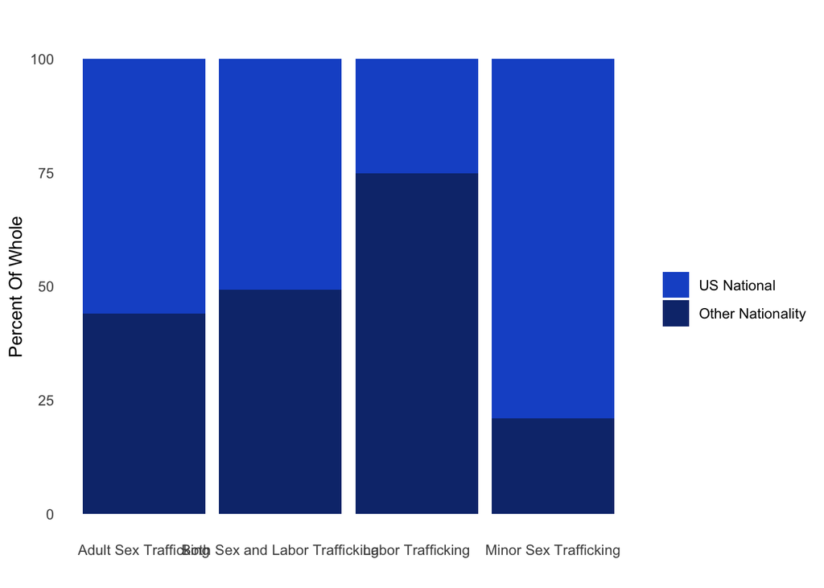

```r
#Stacked Bar Chart
ten <- ggplot(data = dta3, aes(x = trafficking_type.x, y = percent_of_victim, fill = victim_type))+
  geom_bar(position = "stack", stat = "identity")+
  scale_fill_manual(values=(c("#1957CD", "#0F347B" )))+
  ggtitle("") +
  theme_minimal() +
  xlab("") +
  ylab("Percent Of Whole")+
  labs(fill = "")


ten + theme(
  panel.grid.major = element_blank(),
  panel.grid.minor = element_blank(),
  plot.title = element_text(face = "bold", size = 12)
)
```

```r
#Race effect on Gender
mod_race_gender <- glm(gender_binary ~ defendants_race, data=lightHouse, family=binomial())
summary(mod_race_gender)
```

```
##
## Call:
## glm(formula = gender_binary ~ defendants_race, family = binomial(),
##     data = lightHouse)
##
## Coefficients:
##                         Estimate Std. Error z value Pr(>|z|)
## (Intercept)              0.87238    0.07247  12.038  < 2e-16 ***
## defendants_raceAsian    -0.76397    0.14048  -5.438 5.38e-08 ***
## defendants_raceBlack     0.77165    0.09355   8.249  < 2e-16 ***
## defendants_raceHispanic  0.10908    0.11027   0.989    0.323
## defendants_raceOther    -0.02508    0.25451  -0.099    0.922
## ---
## Signif. codes:  0 '***' 0.001 '**' 0.01 '*' 0.05 '.' 0.1 ' ' 1
##
## (Dispersion parameter for binomial family taken to be 1)
##
##     Null deviance: 4479.4  on 4108  degrees of freedom
## Residual deviance: 4312.3  on 4104  degrees of freedom
##   (475 observations deleted due to missingness)
## AIC: 4322.3
##
## Number of Fisher Scoring iterations: 4
```

```r
#Race effect on Age
mod_race_age <- lm(defendants_arrest_age ~ defendants_race, data=lightHouse)
summary(mod_race_age)
```

```
##
## Call:
## lm(formula = defendants_arrest_age ~ defendants_race, data = lightHouse)
##
## Residuals:
##     Min      1Q  Median      3Q     Max
## -22.596  -7.459  -2.350   6.014  52.014
##
## Coefficients:
##                         Estimate Std. Error t value Pr(>|t|)
## (Intercept)              37.9861     0.3654 103.969  < 2e-16 ***
## defendants_raceAsian      3.6104     0.7999   4.513 6.58e-06 ***
## defendants_raceBlack     -7.5272     0.4379 -17.191  < 2e-16 ***
## defendants_raceHispanic  -3.6362     0.5758  -6.315 3.02e-10 ***
## defendants_raceOther      0.9977     1.4127   0.706     0.48
## ---
## Signif. codes:  0 '***' 0.001 '**' 0.01 '*' 0.05 '.' 0.1 ' ' 1
##
## Residual standard error: 10.75 on 3716 degrees of freedom
##   (863 observations deleted due to missingness)
## Multiple R-squared:  0.1098, Adjusted R-squared:  0.1088
## F-statistic: 114.5 on 4 and 3716 DF,  p-value: < 2.2e-16
```

```r
#Race effect on Foreign Nationality
mod_race_forg <- glm(def_forg_binary ~ defendants_race, data=lightHouse, family=binomial())
summary(mod_race_forg)
```

```
##
## Call:
## glm(formula = def_forg_binary ~ defendants_race, family = binomial(),
##     data = lightHouse)
##
## Coefficients:
##                         Estimate Std. Error z value Pr(>|z|)
## (Intercept)              1.59783    0.08779  18.200  < 2e-16 ***
## defendants_raceAsian    -3.22878    0.18358 -17.588  < 2e-16 ***
## defendants_raceBlack     0.53167    0.11270   4.717 2.39e-06 ***
## defendants_raceHispanic -2.88787    0.12561 -22.990  < 2e-16 ***
## defendants_raceOther    -2.30933    0.25085  -9.206  < 2e-16 ***
## ---
## Signif. codes:  0 '***' 0.001 '**' 0.01 '*' 0.05 '.' 0.1 ' ' 1
##
## (Dispersion parameter for binomial family taken to be 1)
##
##     Null deviance: 5054.2  on 4129  degrees of freedom
## Residual deviance: 3385.9  on 4125  degrees of freedom
##   (454 observations deleted due to missingness)
## AIC: 3395.9
##
## Number of Fisher Scoring iterations: 4
```

```r
#Gender effect on Foreign Nationality
mod_gender_forg <- glm(def_forg_binary ~ gender_binary, data=lightHouse, family=binomial())
summary(mod_gender_forg)
```

```
##
## Call:
## glm(formula = def_forg_binary ~ gender_binary, family = binomial(),
##     data = lightHouse)
##
## Coefficients:
##               Estimate Std. Error z value Pr(>|z|)
## (Intercept)    0.45049    0.06192   7.275 3.46e-13 ***
## gender_binary  0.55862    0.07298   7.655 1.94e-14 ***
## ---
## Signif. codes:  0 '***' 0.001 '**' 0.01 '*' 0.05 '.' 0.1 ' ' 1
##
## (Dispersion parameter for binomial family taken to be 1)
##
##     Null deviance: 5499.7  on 4521  degrees of freedom
## Residual deviance: 5442.3  on 4520  degrees of freedom
##   (62 observations deleted due to missingness)
## AIC: 5446.3
##
## Number of Fisher Scoring iterations: 4
```

#Part II - Models ###Models are included with imputation techniques to demonstrate the similarlies between imputed and non-imputed results

#Defendant Model

##Model Code + Clustering

```r
library(lme4)
library(broom)
library(broom.mixed)

#Relevel Race as Comparison
lightHouse$defendants_race <- fct_relevel(lightHouse$defendants_race, "White")

#Create Simplifed Age Variable for best Model Fit
lightHouse$defendant_age_simple <- round((lightHouse$defendants_arrest_age/10),0)


#Model with lme4
mod_def_glm <- glmer(sex_labor ~ defendants_race + (gender_binary)+defendant_age_simple+ def_forg_binary+(1|state_prosecuted/district_prosecuted), family = binomial(), data = lightHouse, na.action= na.omit)
#Model without District Prosecuted to Compare
mod_reduced<- glmer(sex_labor ~ defendants_race + defendant_age_simple+gender_binary+ def_forg_binary+(1|state_prosecuted), family = binomial(), data = lightHouse, na.action= na.omit)

# View  results
tidy_results <- tidy(mod_def_glm)
print(tidy_results)
```

```
## # A tibble: 10 × 7
##    effect   group                   term  estimate std.error statistic   p.value
##    <chr>    <chr>                   <chr>    <dbl>     <dbl>     <dbl>     <dbl>
##  1 fixed    <NA>                    (Int…  2.47e+0    0.367       6.73  1.71e-11
##  2 fixed    <NA>                    defe…  8.30e-1    0.277       2.99  2.77e- 3
##  3 fixed    <NA>                    defe…  1.01e+0    0.212       4.74  2.14e- 6
##  4 fixed    <NA>                    defe…  8.15e-1    0.232       3.52  4.37e- 4
##  5 fixed    <NA>                    defe… -1.60e+0    0.419      -3.82  1.32e- 4
##  6 fixed    <NA>                    gend…  6.25e-1    0.160       3.89  9.95e- 5
##  7 fixed    <NA>                    defe… -5.33e-1    0.0597     -8.93  4.24e-19
##  8 fixed    <NA>                    def_…  2.84e+0    0.197      14.4   4.33e-47
##  9 ran_pars district_prosecuted:st… sd__…  1.22e+0   NA          NA    NA
## 10 ran_pars state_prosecuted        sd__…  6.34e-4   NA          NA    NA
```

```r
#Explore Variance
var_def <- VarCorr(mod_def_glm)

# Likelihood Ratio Test
summary(mod_def_glm)
```

```
## Generalized linear mixed model fit by maximum likelihood (Laplace
##   Approximation) [glmerMod]
##  Family: binomial  ( logit )
## Formula:
## sex_labor ~ defendants_race + (gender_binary) + defendant_age_simple +
##     def_forg_binary + (1 | state_prosecuted/district_prosecuted)
##    Data: lightHouse
##
##      AIC      BIC   logLik deviance df.resid
##   1442.0   1503.9   -711.0   1422.0     3563
##
## Scaled residuals:
##      Min       1Q   Median       3Q      Max
## -11.7855   0.0664   0.1112   0.2197   4.0750
##
## Random effects:
##  Groups                               Name        Variance  Std.Dev.
##  district_prosecuted:state_prosecuted (Intercept) 1.491e+00 1.2209179
##  state_prosecuted                     (Intercept) 4.018e-07 0.0006338
## Number of obs: 3573, groups:
## district_prosecuted:state_prosecuted, 93; state_prosecuted, 54
##
## Fixed effects:
##                         Estimate Std. Error z value Pr(>|z|)
## (Intercept)              2.46621    0.36653   6.729 1.71e-11 ***
## defendants_raceAsian     0.83005    0.27740   2.992 0.002769 **
## defendants_raceBlack     1.00679    0.21240   4.740 2.14e-06 ***
## defendants_raceHispanic  0.81458    0.23163   3.517 0.000437 ***
## defendants_raceOther    -1.60127    0.41895  -3.822 0.000132 ***
## gender_binary            0.62460    0.16049   3.892 9.95e-05 ***
## defendant_age_simple    -0.53324    0.05971  -8.931  < 2e-16 ***
## def_forg_binary          2.84333    0.19728  14.412  < 2e-16 ***
## ---
## Signif. codes:  0 '***' 0.001 '**' 0.01 '*' 0.05 '.' 0.1 ' ' 1
##
## Correlation of Fixed Effects:
##             (Intr) dfnd_A dfnd_B dfnd_H dfnd_O gndr_b dfnd__
## dfndnts_rcA -0.279
## dfndnts_rcB -0.344  0.298
## dfndnts_rcH -0.415  0.417  0.440
## dfndnts_rcO -0.215  0.187  0.191  0.228
## gender_bnry -0.226  0.104 -0.058 -0.040 -0.022
## dfndnt_g_sm -0.672 -0.063  0.171  0.133  0.049 -0.072
## df_frg_bnry -0.190  0.336  0.059  0.406  0.099 -0.017 -0.118
## optimizer (Nelder_Mead) convergence code: 0 (OK)
## Model failed to converge with max|grad| = 0.00219673 (tol = 0.002, component 1)
```

```r
anova(mod_reduced, mod_def_glm)
```

```
## Data: lightHouse
## Models:
## mod_reduced: sex_labor ~ defendants_race + defendant_age_simple + gender_binary + def_forg_binary + (1 | state_prosecuted)
## mod_def_glm: sex_labor ~ defendants_race + (gender_binary) + defendant_age_simple + def_forg_binary + (1 | state_prosecuted/district_prosecuted)
##             npar    AIC    BIC  logLik deviance  Chisq Df Pr(>Chisq)
## mod_reduced    9 1482.4 1538.1 -732.21   1464.4
## mod_def_glm   10 1442.0 1503.9 -711.02   1422.0 42.381  1  7.513e-11 ***
## ---
## Signif. codes:  0 '***' 0.001 '**' 0.01 '*' 0.05 '.' 0.1 ' ' 1
```

##Calculate Predicted Probabilities

```r
library(margins)

new_data <- data.frame(
  defendants_race = "Black",
  gender_binary = 1,
  defendant_age_simple = 3.3,
  def_forg_binary = 1,
  state_prosecuted = "TX",
  district_prosecuted = "Eastern District of Texas"
)


predicted_probability <- predict(mod_def_glm, newdata = new_data, type = "response")

new_data <- data.frame(
  defendants_race = "White",
  gender_binary = 1,
  defendant_age_simple = 3.3,
  def_forg_binary = 1,
  state_prosecuted = "TX",
  district_prosecuted = "Eastern District of Texas"
)


predicted_probability <- predict(mod_def_glm, newdata = new_data, type = "response")


new_data <- data.frame(
  defendants_race = "Asian",
  gender_binary = 0,
  defendant_age_simple = 5,
  def_forg_binary = 0,
  state_prosecuted = "TX",
  district_prosecuted = "Eastern District of Texas"
)


predicted_probability <- predict(mod_def_glm, newdata = new_data, type = "response")


new_data <- data.frame(
  defendants_race = "White",
  gender_binary = 0,
  defendant_age_simple = 4.5,
  def_forg_binary = 0,
  state_prosecuted = "TX",
  district_prosecuted = "Eastern District of Texas"
)


predicted_probability <- predict(mod_def_glm, newdata = new_data, type = "response")
```

```r
#Ensure correct comparison catagory
lightHouse$defendants_race <- fct_relevel(lightHouse$defendants_race, "White")

#Organize Data
dta <- lightHouse %>%
  group_by(defendant_id)%>%
  summarise(
    sex_labor = as.numeric(sex_labor),
    #limitation of mice is that it does not work for character variables, here defendant race is converted to an oridnal factor variable
    defendant_race = factor(defendants_race),
    count_male = sum(as.numeric(case_number_victims_male), na.rm = TRUE),
    count_female = sum(as.numeric(case_number_victims_female), na.rm = TRUE),
    foreign = sum(as.numeric(case_number_victims_foreign), na.rm = TRUE),
    count_total_vic = sum(as.numeric(case_number_victims), na.rm = TRUE),
    percent_minor = coalesce(sum(as.numeric(case_number_victims_minor), na.rm = TRUE), 0) / coalesce(sum(as.numeric(case_number_victims), na.rm = TRUE), 1),
    num_def = sum(as.numeric(case_number_defendants), na.rm = TRUE),
    percent_male = count_male / (count_male + count_female),
    percent_foregin = foreign / count_total_vic,
    gender_binary = ifelse(defendants_gender == "Male",1,
                           ifelse(defendants_gender == "Female",0,NA)),
    def_forg_binary = ifelse(defendants_country_of_origin == "United States",1,0),
    year = as.numeric(case_year)
  )
#Impute using mice
all_imputed <- mice(dta, m=5)
imputed_data <- complete(all_imputed, 1)
imputed_data$state <- lightHouse$state_prosecuted
imputed_data$district <- lightHouse$district_prosecuted
imputed_data$sex_labor <- lightHouse$sex_labor
imputed_data$case <- lightHouse$case_id

#Model with Imputed Data
mod_def_glm <- glmer(sex_labor ~ defendants_race + (gender_binary)+defendant_age_simple+ def_forg_binary+(1|state_prosecuted/district_prosecuted), family = binomial(), data = lightHouse, na.action= na.omit)
#View Results
tidy_results <- tidy(mod_def_glm)
print(tidy_results)
```

```
## # A tibble: 10 × 7
##    effect   group                   term  estimate std.error statistic   p.value
##    <chr>    <chr>                   <chr>    <dbl>     <dbl>     <dbl>     <dbl>
##  1 fixed    <NA>                    (Int…  2.47e+0    0.367       6.73  1.71e-11
##  2 fixed    <NA>                    defe…  8.30e-1    0.277       2.99  2.77e- 3
##  3 fixed    <NA>                    defe…  1.01e+0    0.212       4.74  2.14e- 6
##  4 fixed    <NA>                    defe…  8.15e-1    0.232       3.52  4.37e- 4
##  5 fixed    <NA>                    defe… -1.60e+0    0.419      -3.82  1.32e- 4
##  6 fixed    <NA>                    gend…  6.25e-1    0.160       3.89  9.95e- 5
##  7 fixed    <NA>                    defe… -5.33e-1    0.0597     -8.93  4.24e-19
##  8 fixed    <NA>                    def_…  2.84e+0    0.197      14.4   4.33e-47
##  9 ran_pars district_prosecuted:st… sd__…  1.22e+0   NA          NA    NA
## 10 ran_pars state_prosecuted        sd__…  6.34e-4   NA          NA    NA
```

#Case Level Model

##No-Imputation Model Code + Clustering

```r
library(tidyverse)
library(stargazer)
library(broom.mixed)
library(broom)
library(nlme)
library(MASS)
library(lme4)
library(missMethods)

#Organize Data
case_dta <- allCase %>%
  group_by(case_id) %>%
  mutate(
    count_male = sum(as.numeric(case_number_victims_male), na.rm = TRUE),
    count_female = sum(as.numeric(case_number_victims_female), na.rm = TRUE),
    foreign = sum(as.numeric(case_number_victims_foreign), na.rm = TRUE),
    count_total_vic = sum(as.numeric(case_number_victims), na.rm = TRUE),
    percent_minor = coalesce(sum(as.numeric(case_number_victims_minor), na.rm = TRUE), 0) / coalesce(sum(as.numeric(case_number_victims), na.rm = TRUE), 1),
    num_def = sum(as.numeric(case_number_defendants), na.rm = TRUE),
    percent_male = count_male / (count_male + count_female),
    percent_foregin = foreign / count_total_vic
  )
case_dta$percent_minor <- ifelse(case_dta$percent_minor > 1,1,case_dta$percent_minor)
# Fit the model
mod_case <- glmer(sex_labor ~ percent_male + percent_foregin + count_total_vic + percent_minor + num_def+ (1|state_prosecuted/district_prosecuted), data = case_dta, na.action = na.omit, family = binomial())
summary(mod_case)
```

```
## Generalized linear mixed model fit by maximum likelihood (Laplace
##   Approximation) [glmerMod]
##  Family: binomial  ( logit )
## Formula: sex_labor ~ percent_male + percent_foregin + count_total_vic +
##     percent_minor + num_def + (1 | state_prosecuted/district_prosecuted)
##    Data: case_dta
##
##      AIC      BIC   logLik deviance df.resid
##    335.6    380.3   -159.8    319.6     1953
##
## Scaled residuals:
##      Min       1Q   Median       3Q      Max
## -26.4244   0.0322   0.0403   0.0613   2.3556
##
## Random effects:
##  Groups                               Name        Variance Std.Dev.
##  district_prosecuted:state_prosecuted (Intercept) 0.3241   0.5693
##  state_prosecuted                     (Intercept) 0.4283   0.6545
## Number of obs: 1961, groups:
## district_prosecuted:state_prosecuted, 93; state_prosecuted, 54
##
## Fixed effects:
##                 Estimate Std. Error z value Pr(>|z|)
## (Intercept)      4.90697    0.52212   9.398  < 2e-16 ***
## percent_male    -4.04292    0.61680  -6.555 5.58e-11 ***
## percent_foregin -5.17992    0.49233 -10.521  < 2e-16 ***
## count_total_vic  0.01484    0.01057   1.403 0.160492
## percent_minor    1.62158    0.42531   3.813 0.000137 ***
## num_def          0.14985    0.07210   2.078 0.037680 *
## ---
## Signif. codes:  0 '***' 0.001 '**' 0.01 '*' 0.05 '.' 0.1 ' ' 1
##
## Correlation of Fixed Effects:
##             (Intr) prcnt_ml prcnt_f cnt_t_ prcnt_mn
## percent_mal -0.411
## percnt_frgn -0.777  0.399
## cont_ttl_vc  0.048 -0.285   -0.132
## percent_mnr -0.273 -0.296    0.061   0.157
## num_def     -0.149 -0.008   -0.204  -0.253  0.097
```

```r
mod_reduced<- glmer(sex_labor ~ percent_male + percent_foregin + count_total_vic + percent_minor + num_def+ (1|state_prosecuted), data = case_dta, na.action = na.omit, family = binomial())

anova(mod_case, mod_reduced)
```

```
## Data: case_dta
## Models:
## mod_reduced: sex_labor ~ percent_male + percent_foregin + count_total_vic + percent_minor + num_def + (1 | state_prosecuted)
## mod_case: sex_labor ~ percent_male + percent_foregin + count_total_vic + percent_minor + num_def + (1 | state_prosecuted/district_prosecuted)
##             npar    AIC    BIC  logLik deviance  Chisq Df Pr(>Chisq)
## mod_reduced    7 334.35 373.42 -160.18   320.35
## mod_case       8 335.64 380.29 -159.82   319.64 0.7109  1     0.3991
```

```r
# View  results
tidy_results <- tidy(mod_case)
print(tidy_results)
```

```
## # A tibble: 8 × 7
##   effect   group                    term  estimate std.error statistic   p.value
##   <chr>    <chr>                    <chr>    <dbl>     <dbl>     <dbl>     <dbl>
## 1 fixed    <NA>                     (Int…   4.91      0.522       9.40  5.55e-21
## 2 fixed    <NA>                     perc…  -4.04      0.617      -6.55  5.58e-11
## 3 fixed    <NA>                     perc…  -5.18      0.492     -10.5   6.90e-26
## 4 fixed    <NA>                     coun…   0.0148    0.0106      1.40  1.60e- 1
## 5 fixed    <NA>                     perc…   1.62      0.425       3.81  1.37e- 4
## 6 fixed    <NA>                     num_…   0.150     0.0721      2.08  3.77e- 2
## 7 ran_pars district_prosecuted:sta… sd__…   0.569    NA          NA    NA
## 8 ran_pars state_prosecuted         sd__…   0.654    NA          NA    NA
```

##Calculate Predictive Probabilities

```r
new_data <- data.frame(
  percent_male = .50,
  percent_foregin = .5,
  count_total_vic = 5.1,
  percent_minor = .50,
  num_def =  1.92,
  state_prosecuted = "TX",
  district_prosecuted = "Eastern District of Texas"
)


# Generate predicted probabilities
predicted_probs <- predict(mod_case, newdata = new_data, type = "response")



new_data <- data.frame(
  percent_male = 1,
  percent_foregin = 1,
  count_total_vic = mean(as.numeric(allCase$case_number_victims), na.rm=TRUE),
  percent_minor = 0,
  num_def = mean(allCase$case_number_defendants),
  state_prosecuted = "TX",
  district_prosecuted = "Eastern District of Texas"
)
# Generate predicted probabilities
predicted_probs <- predict(mod_case, newdata = new_data, type = "response")
```

##Imputate and Rerun

```r
#Subset Data
dta <- case_dta[, c("sex_labor", "percent_male", "percent_foregin", "count_total_vic",
                                "percent_minor", "num_def")]

#Impute using mice
all_imputed <- mice(dta, m=5)
imputed_data <- complete(all_imputed, 1)
imputed_data$state <- allCase$state_prosecuted
imputed_data$district <- allCase$district_prosecuted
imputed_data$sex_labor <- allCase$sex_labor
imputed_data$case <- allCase$case_id

#Model with imputed data
mod_case <- glmer(sex_labor ~ percent_male + percent_foregin + count_total_vic + percent_minor + num_def+ (1|state/district), data = imputed_data, na.action = na.omit, family = binomial())
summary(mod_case)
```

```
## Generalized linear mixed model fit by maximum likelihood (Laplace
##   Approximation) [glmerMod]
##  Family: binomial  ( logit )
## Formula: sex_labor ~ percent_male + percent_foregin + count_total_vic +
##     percent_minor + num_def + (1 | state/district)
##    Data: imputed_data
##
##      AIC      BIC   logLik deviance df.resid
##    482.2    528.2   -233.1    466.2     2316
##
## Scaled residuals:
##      Min       1Q   Median       3Q      Max
## -27.7054   0.0501   0.0588   0.0973   4.5834
##
## Random effects:
##  Groups         Name        Variance Std.Dev.
##  district:state (Intercept) 0.04249  0.2061
##  state          (Intercept) 0.32640  0.5713
## Number of obs: 2324, groups:  district:state, 93; state, 54
##
## Fixed effects:
##                  Estimate Std. Error   z value Pr(>|z|)
## (Intercept)      3.958697   0.003306  1197.343   <2e-16 ***
## percent_male    -2.783221   0.003305  -842.142   <2e-16 ***
## percent_foregin -4.403796   0.003304 -1332.709   <2e-16 ***
## count_total_vic -0.003340   0.001843    -1.812     0.07 .
## percent_minor    1.764796   0.003306   533.862   <2e-16 ***
## num_def          0.124210   0.003296    37.686   <2e-16 ***
## ---
## Signif. codes:  0 '***' 0.001 '**' 0.01 '*' 0.05 '.' 0.1 ' ' 1
##
## Correlation of Fixed Effects:
##             (Intr) prcnt_ml prcnt_f cnt_t_ prcnt_mn
## percent_mal  0.000
## percnt_frgn  0.000  0.000
## cont_ttl_vc -0.002 -0.001   -0.003
## percent_mnr  0.000  0.000    0.000   0.000
## num_def      0.000  0.000   -0.001  -0.042  0.000
## optimizer (Nelder_Mead) convergence code: 0 (OK)
## Model failed to converge with max|grad| = 0.0214453 (tol = 0.002, component 1)
```

```r
# View  results
tidy_results <- tidy(mod_case)
print(tidy_results)
```

```
## # A tibble: 8 × 7
##   effect   group          term            estimate std.error statistic p.value
##   <chr>    <chr>          <chr>              <dbl>     <dbl>     <dbl>   <dbl>
## 1 fixed    <NA>           (Intercept)      3.96      0.00331   1197.    0
## 2 fixed    <NA>           percent_male    -2.78      0.00330   -842.    0
## 3 fixed    <NA>           percent_foregin -4.40      0.00330  -1333.    0
## 4 fixed    <NA>           count_total_vic -0.00334   0.00184     -1.81  0.0700
## 5 fixed    <NA>           percent_minor    1.76      0.00331    534.    0
## 6 fixed    <NA>           num_def          0.124     0.00330     37.7   0
## 7 ran_pars district:state sd__(Intercept)  0.206    NA           NA    NA
## 8 ran_pars state          sd__(Intercept)  0.571    NA           NA    NA
```

#Online Appendix

##Figure 1: Predicted Probabilities of Foreign Nationals

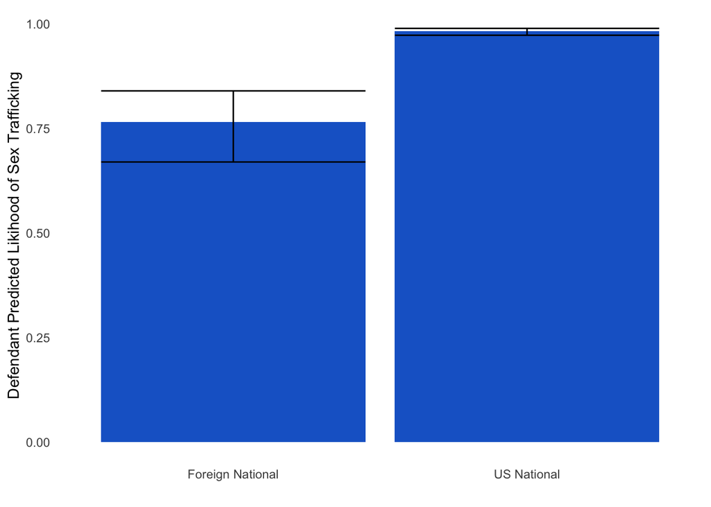

```r
# Load necessary libraries
library(ggeffects)
library(ggplot2)

# Predictor 1: def_forg_binary
predicted_def_forg_binary <- ggpredict(mod_def_glm, terms = "def_forg_binary")

#Chart
foreign <- ggplot(data = predicted_def_forg_binary, aes(x = factor(x), y = predicted)) +
  geom_bar(stat = "identity", position = "dodge",fill= "#1967CD") +
  geom_errorbar(aes(ymin = conf.low, ymax = conf.high))+
  labs(
    x = "",
    y = "Defendant Predicted Likihood of Sex Trafficking")+
    scale_x_discrete(labels = c("Foreign National", "US National")) +
  theme_minimal()

foreign + theme(
  panel.grid.major = element_blank(),
  panel.grid.minor = element_blank(),
  plot.title = element_text(face = "bold", size = 12)
)
```

##Figure 2: Predicted Probabilites of Def. Age

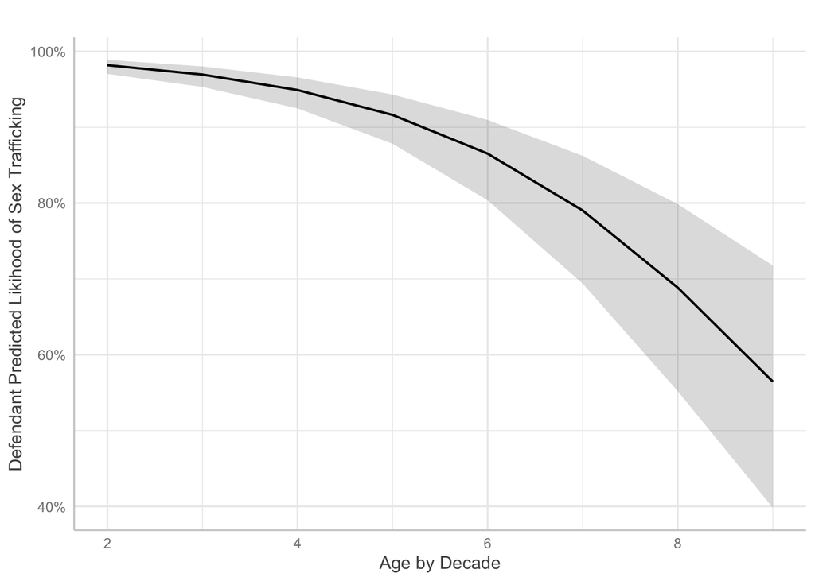

```r
# Predictor 3: defendant_age_simple
predicted_defendant_age_simple <- ggpredict(mod_def_glm, terms = "defendant_age_simple")
plot(predicted_defendant_age_simple)+
  labs(
    x = "Age by Decade",
    y = "Defendant Predicted Likihood of Sex Trafficking",
    title = ""
  )
```

##Figures 3-5 Predictive Probabilities Charts

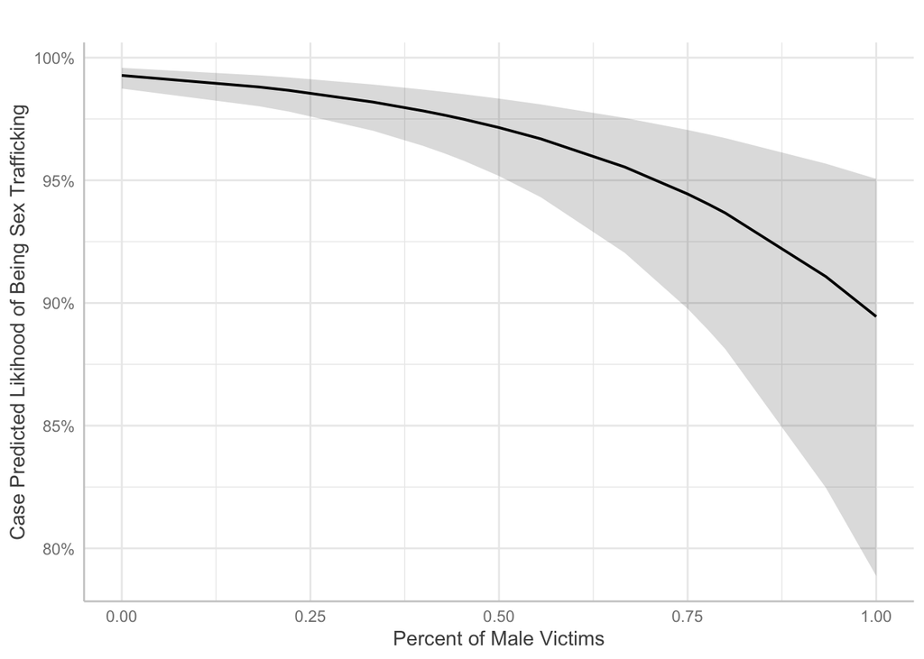

```r
library(ggeffects)

# Generate predicted probabilities for the percent_male predictor
predicted_effect <- ggpredict(mod_case, terms = "percent_male")


plot(predicted_effect)+
  labs(
    x = "Percent of Male Victims",
    y = "Case Predicted Likihood of Being Sex Trafficking",
    title = ""
  )
```

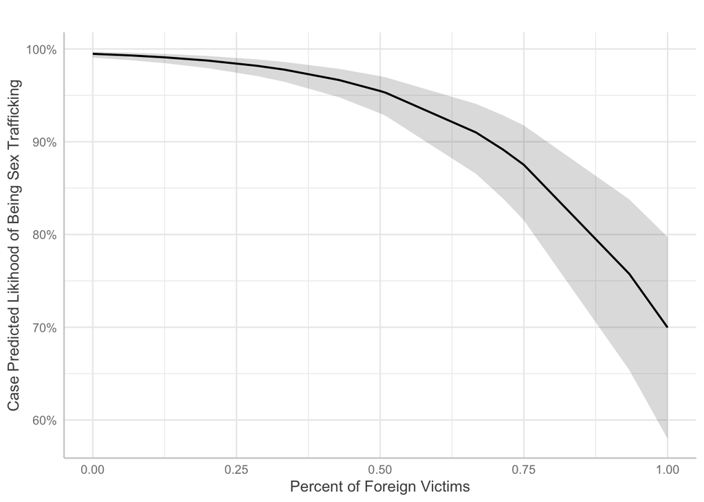

```r
# Predictor 2: percent_foregin
predicted_percent_foregin <- ggpredict(mod_case, terms = "percent_foregin")
plot(predicted_percent_foregin) +
  labs(
    x = "Percent of Foreign Victims",
    y = "Case Predicted Likihood of Being Sex Trafficking",
    title = ""
  )
```

```r
# Predictor 4: percent_minor
predicted_percent_minor <- ggpredict(mod_case, terms = "percent_minor")
```

```
## Data were 'prettified'. Consider using `terms="percent_minor [all]"` to
##   get smooth plots.
```

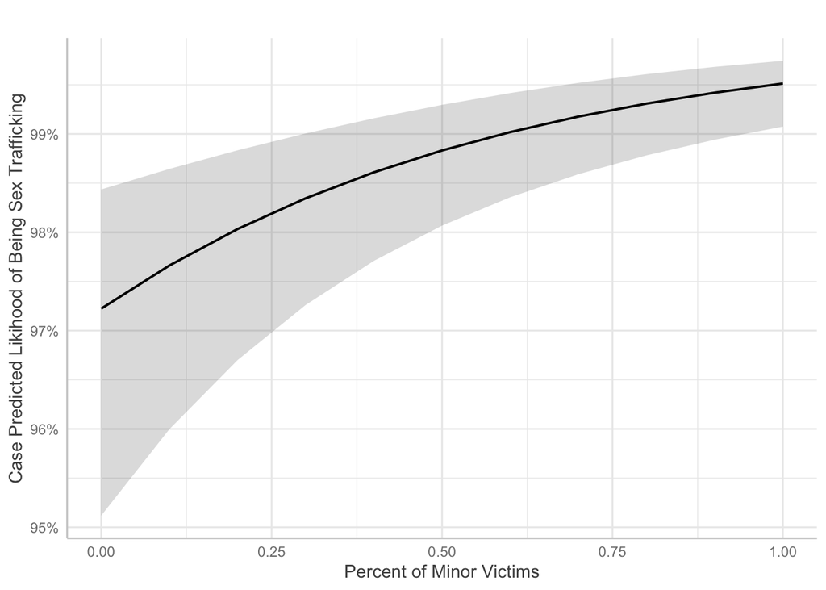

```r
plot(predicted_percent_minor)+
  labs(
    x = "Percent of Minor Victims",
    y = "Case Predicted Likihood of Being Sex Trafficking",
    title = ""
  )
```

```r
table(case_dta$percent_minor)
```

```
##
##                  0               0.02 0.0344827586206897               0.05
##                485                  2                  1                  1
## 0.0588235294117647 0.0666666666666667 0.0674157303370786               0.08
##                  1                  2                  1                  2
## 0.0833333333333333 0.0909090909090909                0.1  0.111111111111111
##                  3                  1                  6                  5
##               0.12              0.125  0.130434782608696  0.133333333333333
##                  1                  4                  1                  2
##  0.142857142857143               0.15  0.166666666666667  0.181818181818182
##                  5                  1                  8                  1
##  0.188405797101449                0.2  0.222222222222222               0.25
##                  1                 23                  6                 28
##  0.285714285714286                0.3  0.307692307692308  0.333333333333333
##                  3                  4                  1                 55
##  0.363636363636364              0.375                0.4  0.416666666666667
##                  1                  2                  7                  1
##  0.428571428571429  0.466666666666667                0.5               0.54
##                  1                  2                125                  1
##  0.545454545454545  0.571428571428571                0.6  0.666666666666667
##                  1                  1                 10                 41
##  0.714285714285714               0.75  0.777777777777778                0.8
##                  7                 16                  2                  7
##  0.833333333333333  0.857142857142857                  1
##                  8                  2               1305
```